# Carbon Pricing and Electricity Demand: Did electricity demand respond more strongly to the Australian carbon pricing policy in states with more carbon-intensive electricity generation?

Adinda Septiani - 33917949

# 1. Introduction

Internalizing carbon has been growing since Finland and Poland introduced the carbon tax in 1990. Australia followed by introducing a carbon price of AUD 23 later in July 2012, making it one of the very few countries to have implemented an explicit carbon pricing mechanism on its electricity sector. However, due to the inherent differences among the Australian states, the electricity mix generation varies significantly, and uniform policies may lead to varying reactions. States with a higher share of coal electricity generation tend to have higher carbon emissions per MWh.

According to this logic, states with high carbon intensity would face larger cost shocks for the electricity customer. Related literature shows that customers bear the cost of the carbon pricing rather than the generator (Nazifi et al., 2021). This raises the question: Did the introduction of carbon pricing have any effect on demand, and did the demand response differ between states based on their carbon intensity? This project aims to determine if electricity demand in more coal-intensive states was associated with a larger demand reduction following the introduction of carbon pricing.

Previous empirical evidence on actual demand responses at the state level during the 2012–2014 policy window remains limited. Existing work focuses primarily on cost pass-through, electricity price, and generation-side adjustments (Nazifi et al., 2021; Wong & Zhang, 2021; O’Gorman & Jotzo, 2014), rather than on heterogeneous demand responses across states with different carbon intensities.

This analysis is descriptive. The coefficients should be interpreted as conditional correlations, which are associated with demand after absorbing fixed differences across states and common time trends, not as treatment effects. Using a balanced state-quarter panel from 2010 to 2014 and a fixed effects regression with a post-policy interaction on coal share, the preferred specification finds a small negative but statistically insignificant association (−0.060, SE = 0.054) between coal intensity and post-policy demand. The direction is consistent across all robustness checks, and significance emerges under alternative specifications that address a near-collinearity problem between coal share and state fixed effects. Temperature enters as a statistically significant quadratic, confirming a U-shaped heating-cooling relationship with demand. The overall finding suggests the carbon price was not associated with a large differential demand response over this short window, consistent with the known short-run inelasticity of electricity demand.

# 2. Data

## 2.1 Data Source

The dataset is constructed from four sources. Electricity demand and price data are drawn from the Australian Energy Market Operator (AEMO), which publishes historical dispatch and settlement data for the NEM at 30-minute intervals. Temperature data are sourced from the Australian Bureau of Meteorology (BOM), aggregated to state-level quarterly averages. Population data are from the Australian Bureau of Statistics (ABS) quarterly population estimates. Coal shares data are from the Department of Climate Change, Energy, the Environment, and Water (DCCEEW).

## 2.2 Sample Construction

The sample covers five NEM states: NSW, QLD, SA, TAS, and VIC. Sample restrictions to the five NEM states are due to the same 30-minute dispatch and settlement system, making their data directly comparable. Including Western Australia and Northern Territory, which are structurally separate from the NEM with a different market mechanism and settlement system, would introduce cross-market heterogeneity unrelated to the research question.

States are observed quarterly from Q1 2010 to Q4 2014, yielding N = 100 state-quarter observations. The time window 2010-2014 is chosen because the carbon price was introduced in July 2012 and repealed in July 2014. The repeal creates a natural upper bound and makes including post-repeal data would conflate the policy period with its removal. The pre-policy window is set symmetrically: Q1 2010 gives 10 quarters before and 10 quarters after the policy, supporting visual inspection of pre-policy trends and avoiding undue weight on either regime. The panel is balanced: every state is observed in every period. Observations without population data were dropped during the cleaning process, as population is a required control variable.

Table 1. Sample Construction

| Step | Observation | Detail |
| --- | --- | --- |
| Raw 30-min AEMO dispatch data, 2010–2014 | 438,240 |  |
| Aggregate to monthly state average | 305 | Aggregated, Drop None |
| Merge with energy mix, 2010–2014 | 300 | Drop 5 (12 a.m. 2015 data) |
| Merge with temperature data, 2010–2014 | 300 | Drop None |
| Merge with quarter population data | 100 | Drop 200 (non-quarter months) |
| Analysis sample | 100 |  |

Note: This table summarises the data construction process from raw 30-minute AEMO dispatch data to the final analysis sample. Observations are sequentially reduced due to aggregation, merging with auxiliary datasets (energy mix, temperature, and population), and alignment of data frequency. The final sample consists of 100 state–quarter observations used in the regression analysis.

## 2.3 Key Variables

The outcome variable is average quarterly electricity demand (MWh), log-transformed to address right-skew and multi-modal distribution. The key explanatory variable is the interaction of a post-July 2012 indicator with each state’s coal share in electricity generation. Coal share proxies for the carbon intensity of the state’s generation mix and the magnitude of the implicit cost shock from the carbon price. Controls include temperature (entered as a quadratic following a U-shaped relationship) and log population. Temperature data is used as a control variable because weather conditions influence the use of cooling and heating load. Meanwhile, population data is included as electricity demand generally increases with population size.

Price is excluded from the specification. As a likely mediator between carbon pricing and demand, the policy raised generation costs which passed through to prices, which then reduced demand. Including price would absorb part of the association of interest. Additionally, wholesale electricity prices are simultaneously determined with demand, meaning the price coefficient would be endogenous and unreliable as a control.

## 2.4 Summary Statistics

Table 2. Summary Statistics

| Variable | Mean | SD | Min | Max | N |
| --- | --- | --- | --- | --- | --- |
| Demand (MWh) | 4,432.61 | 2,778.88 | 1,024.55 | 9,542.50 | 100 |
| Coal Share (0–1) | 0.53 | 0.36 | 0.00 | 0.90 | 100 |
| Temperature (°C) | 17.51 | 4.42 | 8.90 | 25.75 | 100 |
| Population (persons) | 3,950,060.10 | 2,539,533.54 | 508,182.00 | 7,562,171.00 | 100 |
| Share post-July 2012 | 50% | — | 0 | 1 | 100 |

Notes: Demand is average quarterly electricity demand in megawatt-hours (MWh). Coal Share is the proportion of electricity generated from coal (0 = no coal, 1 = fully coal-powered). Temperature is the average quarterly temperature in degrees Celsius. Population is quarterly estimated resident population in persons. Share post-July 2012 reports the proportion of observations in the post-policy period.

Demand ranges widely across states: from 1,024.5 MWh (TAS) to over 9,542.5 MWh (NSW). It reflects dramatic differences in state size and industrial composition, which is supported by the difference in population size. Coal share varies from 0 (TAS, fully hydro) to approximately 0.90 (NSW, VIC). Temperature ranges from approximately 8.9°C to 25.8°C across states and seasons, capturing both heating-season winters and cooling-season summers. The sample is split roughly evenly between pre-policy (50 observations) and post-policy (50 observations) periods.

# 3. Empirical Strategy

## 3.1 Declaration

This analysis is descriptive. It estimates the conditional association between coal intensity and electricity demand following carbon pricing, using a balanced state-level panel. No claim is made that the estimated relationships are causal. Because all five National Electricity Market (NEM) states were subject to the same policy simultaneously, there is no untreated control group, and a causal identification strategy is not available.

## 3.2Specification

The outcome variable is the log of average quarterly electricity demand. Taking logs reduces the influence of right-skew visible in the raw distribution and allows coefficients to be interpreted as approximate percentage changes, which more meaningful scale given the drastic baseline demand level (Figure A.1). The main equation estimated is:

$$\log(\text{demand}_{it}) = \alpha_i + \lambda_t
+ \beta_1 \, (\text{post}_{t} \times \text{coalshare}_{i})
+ \beta_2 \, \text{post}_{t}
+ \gamma_1 \, \text{temp}_{it}
+ \gamma_2 \, \text{temp}_{it}^2
+ \gamma_3 \log(\text{pop}_{it})
+ \varepsilon_{it}$$

where $i$ indexes state and $t$ indexes quarter-year. $\alpha_i$ are state fixed effects, absorbing all time-invariant state-level differences (e.g., industrial structure, climate zone). $\lambda_t$ are time fixed effects, absorbing common shocks in each period (e.g., national business cycle, energy market conditions). The key variable is $\text{post}_{t} \times\text{coalshare}_{i}$, which captures whether the post-policy demand trajectory differed systematically across states with different coal intensities. Temperature enters as a quadratic ($\text{temp}_{it}$ and $\text{temp}_{it}^2$) because the EDA revealed a U-shaped within-state relationship between temperature and demand (Figure A.2), consistent with dual heating and cooling load. Population is log-transformed due to right-skew and large-scale difference between states (Figure A.3). Three specifications are estimated: pooled OLS (no fixed effects), state FE only, and state + time FE (preferred).

## 3.3 Error Structure

Standard errors are clustered at the state level to allow for arbitrary serial correlation within states over time. If an unobserved demand shock affects a state in one quarter, it likely persists into adjacent quarters, and ignoring this would leave the failed independence assumption unsolved. Clustering allows the variance-covariance matrix to be fully unrestricted within each state across all time periods. A known limitation is that cluster-robust inference requires many clusters to be reliable, ideally 30 or more. With G = 5 states, the estimator may understate true standard errors. Significance results should be interpreted cautiously. HC3 robust standard errors are reported as a robustness check.

# 4. Results

The Post × Coal Share coefficient moves from 0.145 (pooled OLS) to −0.016 (state FE) to −0.060 (state + time FE). The pooled positive result reflects a cross-state size confound; large coal-intensive states (NSW, VIC) have higher demand regardless of the policy. Once state fixed effects absorb those persistent differences, the coefficient flips negative and remains so in the specification.

The preferred specification is −0.060 (SE = 0.054), meaning moving from a coal share of 0 to a coal share of 0.1 (e.g., from 0.7 to 0.8) is associated with approximately 0.6% lower electricity demand in the post-policy period relative to the pre-policy period, holding state fixed effects, time effects, temperature, and population constant. Over the full 0-to-1 range of coal share, this implies approximately 6% lower demand. This association is not statistically significant at conventional levels (p > 0.1). As with all coefficients in this analysis, this should be interpreted as a conditional association rather than a causal effect.

Although the result is statistically insignificant in the preferred specification, the magnitude is economically plausible. A 6% demand differential across the full coal share range is consistent with the known short-run inelasticity of electricity demand, households and businesses do not rapidly change consumption patterns in response to price signals, and the energy generation mix cannot shift immediately. The transition away from coal is a structural process unfolding over decades, not quarters. Detecting a strong differential response over a 2.5-year window would be unlikely even if the carbon price had meaningful long-run effects.

Moreover, a study reveals a reversal in energy transmissions. VIC, which exports its wholesale electricity to TAS, becomes the importer of wholesale energy from TAS during the policy. This shift results in a significant increase in energy imports, ranging from approximately 802% to 1,170% more energy compared to what it exported before (Wong & Zhang, 2021). This imported energy explains how states can keep their high electricity demand despite their coal share remaining relatively unchanged after the implementation of carbon pricing.

Table 3. Main Result

|  | Pooled OLS | Within-State State FE | Within-State & Time State+Time FE |
| --- | --- | --- | --- |
| Post × Coal Share | 0.145 | −0.016 | −0.060 |
|  | (0.138) | (0.043) | (0.054) |
| Post July 2012 | −0.147 | −0.011 |  |
|  | (0.108) | (0.020) |  |
| Temperature | −0.139*** | −0.081*** | −0.059** |
|  | (0.037) | (0.008) | (0.014) |
| Temperature² | 0.004*** | 0.002*** | 0.002*** |
|  | (0.001) | (0.000) | (0.000) |
| Log(Population) | 0.778*** | −1.024* | 0.180 |
|  | (0.034) | (0.449) | (0.980) |
| Num.Obs. | 100 | 100 | 100 |
| R2 | 0.917 | 0.998 | 0.999 |
| R2 Adj. | 0.912 | 0.998 | 0.999 |

Temperature enters as a quadratic, with a linear term of −0.059 (significant at 5%) and a squared term of 0.002 (significant at 1%). These confirm the U-shaped relationship identified in the EDA (Figure A.2). Demand reaches its minimum at approximately 14.75°C, where colder temperatures drive heating load and warmer temperatures drive cooling load. Both terms are statistically significant, supporting the non-linear specification. A 1% increase in population is associated with a 0.180% increase in electricity demand (SE = 0.980), but the coefficient is insignificant, consistent with minimal population variation within states over the short window, limiting the fixed effects estimator’s ability to exploit. As with all results, this is a conditional association rather than a causal effect.

# 5. Robustness

Applying HC3 reduces the SE slightly from 0.045 to 0.043, pushing significance from the 10% to the 5% level. This occurs because HC3 adjusts only for heteroskedasticity, which appears limited based on the residual diagnostics (Figure A.4), while clustered standard errors may be inflated and unreliable due to the small number of clusters. As a result, HC3 produces a more precise estimate in this setting, increasing the t-statistic without changing the coefficient itself. Together, this suggests that the larger negative estimate of −0.098 arises from separating coal share from the state fixed effects, which improves precision by reducing collinearity. Applying HC3 standard errors further reduces the estimated uncertainty, bringing the result below the 5% significance threshold. However, this reflects sensitivity to the choice of inference method rather than definitive evidence of a precisely estimated effect. The preferred specification’s insignificance likely reflects limited precision arising from near-collinearity between coal share and state fixed effects, rather than clear evidence of no association.

Table 4. Robustness Checks

|  | Main Preferred | Alt.Ctrl No Ctrl | Alt.Ctrl Coal Lvl | Alt.Sample No TAS | Alt.Sample 2011-2013 | Alt.SE HC3 | Alt.SE Coal+HC3 | Placebo |
| --- | --- | --- | --- | --- | --- | --- | --- | --- |
| Post × Coal Share | −0.060 | −0.033 | −0.098* | −0.052 | −0.085 | −0.060 | −0.098** |  |
|  | (0.054) | (0.039) | (0.045) | (0.030) | (0.044) | (0.038) | (0.043) |  |
| Placebo × Coal Share |  |  |  |  |  |  |  | −0.011 |
|  |  |  |  |  |  |  |  | (0.025) |
| Coal Share (level) |  |  | 0.436*** |  |  |  | 0.436** |  |
|  |  |  | (0.084) |  |  |  | (0.167) |  |
| Temperature | −0.059** |  | −0.059** | −0.063** | −0.048** | −0.059*** | −0.059*** | −0.058** |
|  | (0.014) |  | (0.014) | (0.018) | (0.017) | (0.010) | (0.010) | (0.018) |
| Temperature² | 0.002*** |  | 0.002*** | 0.002** | 0.002*** | 0.002*** | 0.002*** | 0.002** |
|  | (0.000) |  | (0.000) | (0.000) | (0.000) | (0.000) | (0.000) | (0.000) |
| Log(Population) | 0.180 |  | 1.101 | 1.783 | 0.934 | 0.180 | 1.101 | 1.058 |
|  | (0.980) |  | (0.906) | (1.027) | (1.094) | (0.706) | (0.822) | (0.952) |
| Num.Obs. | 100 | 100 | 100 | 80 | 60 | 100 | 100 | 60 |
| R2 | 0.999 | 0.997 | 0.999 | 0.999 | 0.999 | 0.999 | 0.999 | 0.999 |

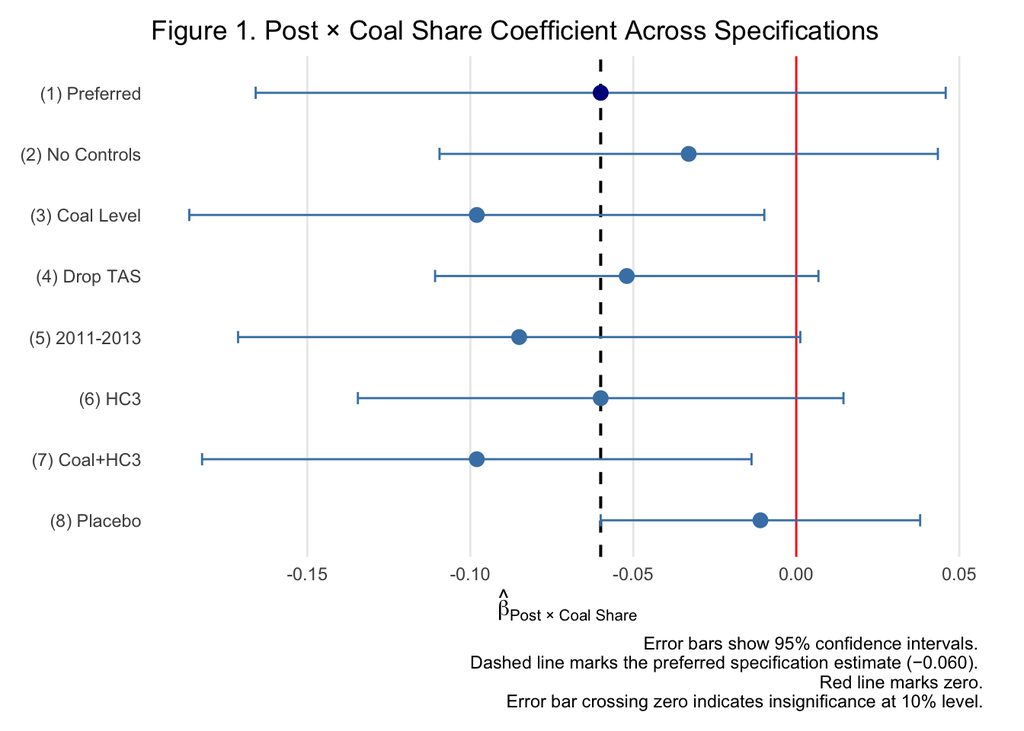

# 6 Discussion and Limitations

This analysis cannot conclude that carbon pricing caused the demand reduction. Because all five NEM states were subject to the policy simultaneously, there is no untreated control group. The coefficients are conditional correlations, not treatment effects. The absence of a large demand response is itself a meaningful finding, consistent with the short-run inelasticity of electricity demand and the structural constraints on energy mix adjustment.

The main remaining threat to interpretation is the presence of time-varying omitted confounders. While state fixed effects absorb persistent cross-state differences, they cannot account for state-specific changes over time that are correlated with coal intensity. Two mechanisms are particularly plausible. First, several states introduced energy efficiency programs around the policy period; if these were more prevalent in coal-intensive states, part of the observed decline in electricity demand may reflect efficiency improvements rather than a behavioural response to carbon pricing. Second, coal-intensive states had a higher concentration of energy-intensive industries, which declined over this period due to broader structural changes unrelated to the policy. Both mechanisms would likely bias the estimated relationship downward, making the effect appear more negative than it truly is.

A further limitation arises from interstate electricity trade, as electricity demand is measured at the state level while generation and consumption are interconnected across regions. High-coal states may have reduced local generation and increased imports following the carbon price, implying that observed demand changes may partly reflect generation substitution across states rather than true consumption responses.

In addition, measurement constraints affect the analysis: coal share exhibits limited within-state variation over the sample period, reducing the precision of the interaction estimate by limiting identifying variation, and the use of quarterly aggregation smooths short-run demand responses. Finally, inference is constrained by the small number of clusters (G = 5), as cluster-robust standard errors are known to be unreliable in such settings. Although HC3 robust standard errors are reported as a robustness check, results remain sensitive to inference assumptions and should be interpreted with caution.

Future research could address these limitations by employing higher-frequency data (e.g., monthly or weekly) to better capture short-run demand responses and seasonal patterns, extending the time horizon to include post-policy or post-repeal periods for a clearer before–during–after comparison, and adopting a quasi-experimental design. In particular, incorporating a comparison market such as Western Australia, with appropriate controls for differences in market structure, could strengthen causal identification.

## 7. Conclusion

# References List

Australian Bureau of Statistics. (2025). *National, state and territory population*. https://www.abs.gov.au/statistics/people/population/national-state-and-territory-population/latest-release

Australian Energy Market Operator. (n.d.). *Aggregated price and demand data*. https://www.aemo.com.au/energy-systems/electricity/national-electricity-market-nem/data-nem/aggregated-data

Bureau of Meteorology. (n.d.). *Climate Data Online*. Australian Government. https://www.bom.gov.au/climate/data/

Department of Climate Change, Energy, the Environment and Water. (2025). *Australian energy update 2025*. Australian Government. https://www.energy.gov.au/publications/australian-energy-update-2025

Nazifi, F., Trück, S., & Zhu, L. (2021). Carbon pass-through rates on spot electricity prices in Australia. *Energy Economics*, *96*, 105178. https://doi.org/10.1016/j.eneco.2021.105178

O’Gorman, M., & Jotzo, F. (2014). Impact of the carbon price on Australia’s electricity demand, supply and emissions. *SSRN Electronic Journal*. https://doi.org/10.2139/ssrn.2731384

Wong, J. B., & Zhang, Q. (2021). Impact of carbon tax on electricity prices and behaviour. *Finance Research Letters*, *44*, 102098. https://doi.org/10.1016/j.frl.2021.102098

# Appendix A

## A.1 Electricity Demand by States Over Time

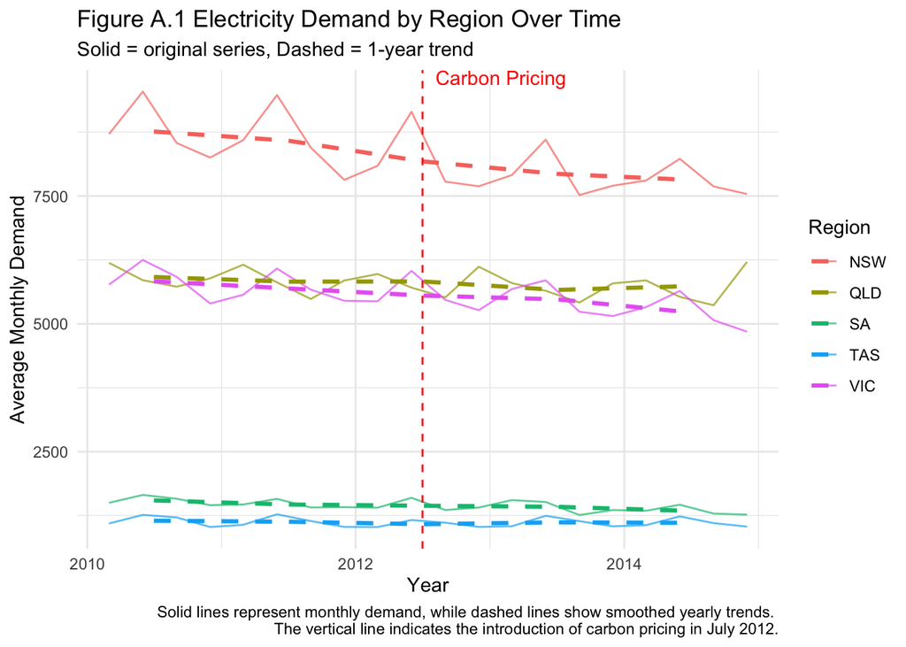

## A.2. Electricity Demand and Temperature Relationship

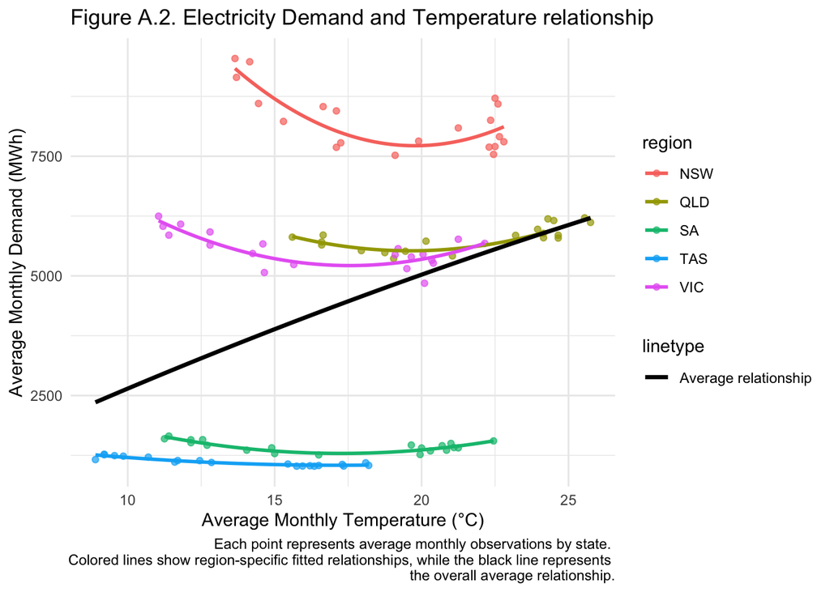

## A.3. Population by States Over Time

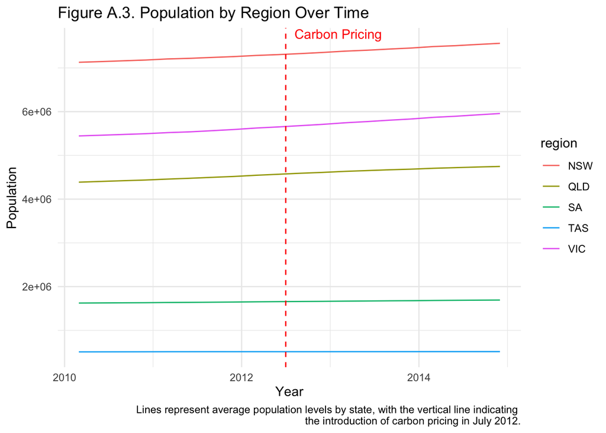

## A.4. Residual vs Fitted Value

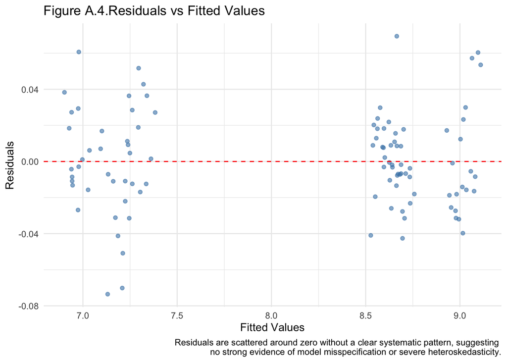